# Generalized Assignment Problem

## About

This page contains an automatic benchmark between the C++ library idol and the Julia package [coluna.jl](https://github.com/atoptima/Coluna.jl) to test their implementation of the [Branch-and-Price algorithm](https://en.wikipedia.org/wiki/Branch_and_price) for solving instances of the [Generalized Assignment Problem](https://en.wikipedia.org/wiki/Generalized_assignment_problem).

The results presented here are automatically generated using GitHub Actions and R with Rmarkdown. Note that the experiments themselves were run on GitHub Actions for which the code is fully public and can be found [here for implementation details](https://github.com/hlefebvr/idol_benchmark) and [here for GitHub Actions configuration](https://github.com/hlefebvr/idol_benchmark/blob/main/.github/workflows/benchmark.yml).

The experiments were conducted on a GitHub-hosted runner with an `ubuntu-latest` virtual machine with two CPU cores (x86_64), 7 GB of RAM and 14 GB of SSD space (see [hardware specifications here](https://docs.github.com/en/actions/using-github-hosted-runners/about-github-hosted-runners)).

Last automatic run: 12/01/23 23:06:09.

## Mathematical models

### Direct model

Let $m$ be a given of agents and let $n$ be a set of tasks to perform. Let $c_{ij}$ be the cost of assigning task $j$ to agent $i$, $w_{ij}$ be the resource consumption of task $j$ when performed by agent $i$ and let $t_i$ be the resource capacity of agent $i$. The Generalized Assignment Problem (GAP) can be modeled as

$$\begin{array}{lll}
\textrm{minimize } & \displaystyle \sum_{i=1}^m \sum_{j=1}^n
c_{ij} x_{ij} \\
\textrm{subject to } & \displaystyle \sum_{j=1}^n w_{ij}x_{ij}
\le t_{i} & i=1,...,m \\
& \displaystyle \sum_{i=1}^m x_{ij} = 1 & j = 1,...,n \\
& x_{ij} \in \{ 0,1 \}.
\end{array}$$
Here, variable $x_{ij}$ encodes the assignment decision and equals $1$ if and only if task $j$ is assigned to agent $i$.

### Dantzig-Wolfe reformulation

Let us enumerate the list of all feasible assignments, i.e., let $\{ \bar{\mathrm{x}}_{ij}^e \}_{e\in E} = \{ x\in\{ 0, 1 \}^{mn} | \sum_{j=1}^n w_{ij}x_{ij} \le t_i \quad i = 1,...,m \}$ where $E$ denotes a list for their indices. The [Dantzig-Wolfe reformulation](https://en.wikipedia.org/wiki/Dantzig%E2%80%93Wolfe_decomposition) of GAP reads

$$\begin{array}{lll}
\textrm{minimize } & \displaystyle \sum_{e\in E} \alpha_e \left(
\sum_{i=1}^m\sum_{j=1}^n c_{ij}\bar{\mathrm{x}}_{ij}^e \right) \\
\textrm{subject to } & \displaystyle \sum_{i=1}^m
\alpha_e\bar{\mathrm{x}}_{ij}^e = 1 & j=1,...,n \\
& \displaystyle \sum_{e\in E} \alpha_e = 1 \\
& \alpha_e \ge 0
\end{array}$$

Though this model contains an exponential number of variables (i.e., columns) it can still be solved efficiently using [Column Generation](https://en.wikipedia.org/wiki/Column_generation) and [Branch and price](https://en.wikipedia.org/wiki/Branch_and_price). In such case, the pricing problem is a [Knapsack Problem](https://en.wikipedia.org/wiki/Knapsack_problem).

## Reading instances

In this section, we start by reading the raw computational results stored in CSV files. Note that these CSV files is stored as an *artifact* on the [GitHub Actions of the hlefebvr/idol_benchmark repository](https://github.com/hlefebvr/idol_benchmark/actions) and can be downloaded without restrictions by clicking on the latest workflow execution named `new_workflow` under the section “Artifacts” (also note that artifacts have a life span of 90 days).

```r
time_limit = 10 * 60
```

### Results obtained with Idol

We first start to read results obtained using idol, which can be found inside the `results_GAP_idol.csv` file (Note that this file can be obtained by running `cat results_GAP_idol__*.csv > results_GAP_idol.csv` after having extracted the `.zip` the artifact).

```r
idol = read.csv("../results_GAP_idol.csv", header = FALSE)
colnames(idol) = c("instance", "solver", "with_heuristics", "smoothing_factor", "farkas_pricing", "clean_up_threshold", "branching_on_master", "n_agents", "n_jobs", "status", "reason", "objective_value", "time")
```

```r
idol[idol$solver == "external_solver",]$with_heuristics = NA
idol[idol$solver == "external_solver" | idol$solver == "idol_bab",]$smoothing_factor = NA
idol[idol$solver == "external_solver" | idol$solver == "idol_bab",]$farkas_pricing = NA
idol[idol$solver == "external_solver" | idol$solver == "idol_bab",]$clean_up_threshold = NA
idol[idol$solver == "external_solver" | idol$solver == "idol_bab",]$branching_on_master = NA
```

Then, we concatenate the parameter values with the method’s name to obtain a unique identifier for each tested method. The unique identifier can be `external_solver`, `idol_bab_h<A>` or `idol_bap_h<A>_s<B>_f<C>_c<D>_m<E>` where

- `<A>` is 1 if the algorithm uses primal heuristics, 0 otherwise ;
- `<B>` is the smoothing factor (when relevant) multiplied by 100 ;
- `<C>` is 1 if Farkas pricing was used, 0 if artificial variables were used ;
- `<D>` is the clean up threshold which was used (when the threshold is reached, up to 1/3 of the threshold columns are removed from the pool) ;
- `<E>` is 1 branching was applied to the master problem and 0 otherwise.

```r
idol$solver_with_params = paste0(idol$solver, "_h", idol$with_heuristics, "_s", idol$smoothing_factor * 100, "_f", idol$farkas_pricing, "_c", idol$clean_up, "_m", idol$branching_on_master)
idol[idol$solver == "external_solver",]$solver_with_params = "external_solver"
idol[idol$solver == "idol_bab",]$solver_with_params = paste0("idol_bab_h", idol[idol$solver == "idol_bab",]$with_heuristics)
```

### Results obtained with coluna.jl

The results obtained using coluna can be found inside `results_GAP_coluna.csv`.

```r
coluna =  read.csv("../results_GAP_coluna.csv", header = FALSE)
colnames(coluna) = c("instance", "solver", "with_heuristics", "smoothing_factor", "farkas_pricing", "clean_up_threshold", "branching_on_master", "status", "reason", "n_agents", "n_jobs", "objective_value", "time")
coluna$solver_with_params = "coluna"

coluna[coluna$status == "ERROR",]$time = time_limit
```

### All

We can now combine and print out the obtained computational results for each instance for each solver.

```r
results = rbind(idol, coluna)
```

| instance | solver | with_heuristics | smoothing_factor | farkas_pricing | clean_up_threshold | branching_on_master | n_agents | n_jobs | status | reason | objective_value | time | solver_with_params |
| --- | --- | --- | --- | --- | --- | --- | --- | --- | --- | --- | --- | --- | --- |
| ./GAP/data/n2/instance_n2_30__0.txt | idol_bap | 1 | 0.3 | 0 | 1500 | 1 | 2 | 30 | Optimal | Proved | 8.590e+02 | 0.272060 | idol_bap_h1_s30_f0_c1500_m1 |
| ./GAP/data/n2/instance_n2_30__1.txt | idol_bap | 1 | 0.3 | 0 | 1500 | 1 | 2 | 30 | Infeasible | Proved | 1.000e+20 | 0.398565 | idol_bap_h1_s30_f0_c1500_m1 |
| ./GAP/data/n2/instance_n2_30__10.txt | idol_bap | 1 | 0.3 | 0 | 1500 | 1 | 2 | 30 | Optimal | Proved | 7.070e+02 | 0.672454 | idol_bap_h1_s30_f0_c1500_m1 |
| ./GAP/data/n2/instance_n2_30__11.txt | idol_bap | 1 | 0.3 | 0 | 1500 | 1 | 2 | 30 | Optimal | Proved | 8.480e+02 | 0.261386 | idol_bap_h1_s30_f0_c1500_m1 |
| ./GAP/data/n2/instance_n2_30__12.txt | idol_bap | 1 | 0.3 | 0 | 1500 | 1 | 2 | 30 | Infeasible | Proved | 1.000e+20 | 2.374350 | idol_bap_h1_s30_f0_c1500_m1 |
| ./GAP/data/n2/instance_n2_30__13.txt | idol_bap | 1 | 0.3 | 0 | 1500 | 1 | 2 | 30 | Optimal | Proved | 8.060e+02 | 1.196670 | idol_bap_h1_s30_f0_c1500_m1 |
| ./GAP/data/n2/instance_n2_30__14.txt | idol_bap | 1 | 0.3 | 0 | 1500 | 1 | 2 | 30 | Optimal | Proved | 8.040e+02 | 0.341681 | idol_bap_h1_s30_f0_c1500_m1 |
| ./GAP/data/n2/instance_n2_30__15.txt | idol_bap | 1 | 0.3 | 0 | 1500 | 1 | 2 | 30 | Optimal | Proved | 7.970e+02 | 0.215496 | idol_bap_h1_s30_f0_c1500_m1 |
| ./GAP/data/n2/instance_n2_30__16.txt | idol_bap | 1 | 0.3 | 0 | 1500 | 1 | 2 | 30 | Optimal | Proved | 8.280e+02 | 1.033310 | idol_bap_h1_s30_f0_c1500_m1 |
| ./GAP/data/n2/instance_n2_30__17.txt | idol_bap | 1 | 0.3 | 0 | 1500 | 1 | 2 | 30 | Optimal | Proved | 8.790e+02 | 0.400490 | idol_bap_h1_s30_f0_c1500_m1 |

[output cut: 710 more lines]

The list of all tested configuration of solvers can be obtained as follows.

```r
solvers = as.data.frame(unique(results$solver_with_params))
solvers = as.data.frame(sort(solvers[,1], decreasing = TRUE))
colnames(solvers) = "Solver"
```

| Solver |
| --- |
| idol_bap_h1_s80_f0_c1500_m1 |
| idol_bap_h1_s30_f0_c1500_m1 |
| idol_bap_h1_s0_f1_c1500_m1 |
| idol_bap_h1_s0_f0_c1500_m1 |
| idol_bap_h1_s0_f0_c1500_m0 |
| idol_bab_h1 |
| idol_bab_h0 |
| external_solver |
| coluna |

```r
colors = cbind(solvers, rainbow(nrow(solvers)))
```

## Checking results

```r
solved_results = results[results$time < time_limit,]

compare_results = function (dataset, solver_a, solver_b) {

  results_a = dataset[dataset$solver_with_params == solver_a & dataset$time < time_limit,]
  results_b = dataset[dataset$solver_with_params == solver_b & dataset$time < time_limit,]

  merged = merge(results_a, results_b, by = c("instance"))

  return ( merged[ abs(merged$objective_value.x - merged$objective_value.y) > 1e-2 ,] )
}
```

Then, we compare all solvers together.

```r
for (solver_with_params in unique(results$solver_with_params)) {
  mismatch = compare_results(results, "external_solver", solver_with_params)
  if (nrow(mismatch) > 0) {
    paged_table(mismatch)
  }
}
```

## Some helper functions

### Performance profiles

To compare the different methods, we use performance profiles as introduced in [Dolan et al. (2002)](https://link.springer.com/article/10.1007/s101070100263). The following function is used to compute and plot the performance profile of a given dataset.

```r
performance_profile = function (dataset, xlim = NULL, main = "Performance profile") {

  solvers = unique(dataset$solver_with_params)
  times = spread(dataset[,c("instance", "solver_with_params", "time")], key = solver_with_params, value = time)
  #times = na.omit(times)
  times$time.best = apply(times[,-1], 1, FUN = min)

  ratios = times[,-ncol(times)][,-1] / times$time.best
  colnames(ratios) = paste0(colnames(ratios), ".ratio")

  worst_ratio = max(ratios)

  times = cbind(times, ratios)

  for (solver in solvers) {
    time_limit_filter = times[,solver] >= time_limit
    if ( sum(time_limit_filter) > 0 ) {
      times[time_limit_filter, paste0(solver, ".ratio")] = worst_ratio
    }
  }

  if (is.null(xlim)) {
    xlim = c(1, worst_ratio)
  }

  par(mar = c(5,4,4,8))

  using_colors = NULL

  index = 1
  for (solver in solvers) {

    plot_function = if (index == 1) plot else lines

    profile = ecdf(times[,paste0(solver, ".ratio")])

    using_color =  colors[colors$Solver == solver,2]
    using_colors = rbind(using_colors, using_color)

    plot_function(profile, xlim = xlim, ylim = c(0,1), lty = "solid", cex = 0, col = using_color, main = "", xlab = "", ylab = "")

    index = index + 1
  }

  # Set the plot title
  title(main = main,
        xlab = "Performance ratio",
        ylab = "ECDF")

  # Set the plot legend
  legend(
    "topright",
    inset=c(-.35, 0),
    legend = solvers,
    lty = "solid",
    col = using_colors,
    cex = .5,
    xpd = TRUE,
    bty = "n"
  )

}
```

For instance, the following executation will plot a performance profile over all tested methods.

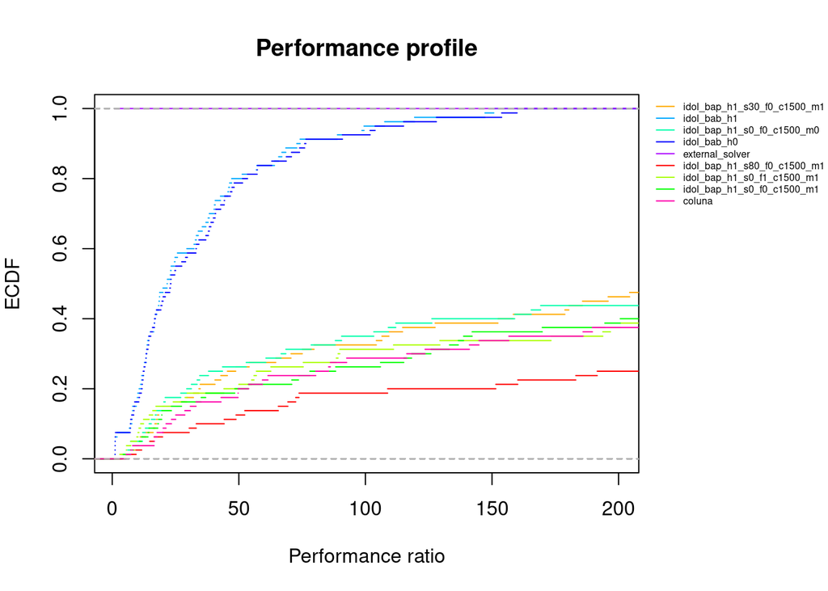

```r
performance_profile(results, xlim = c(1, 200))
```

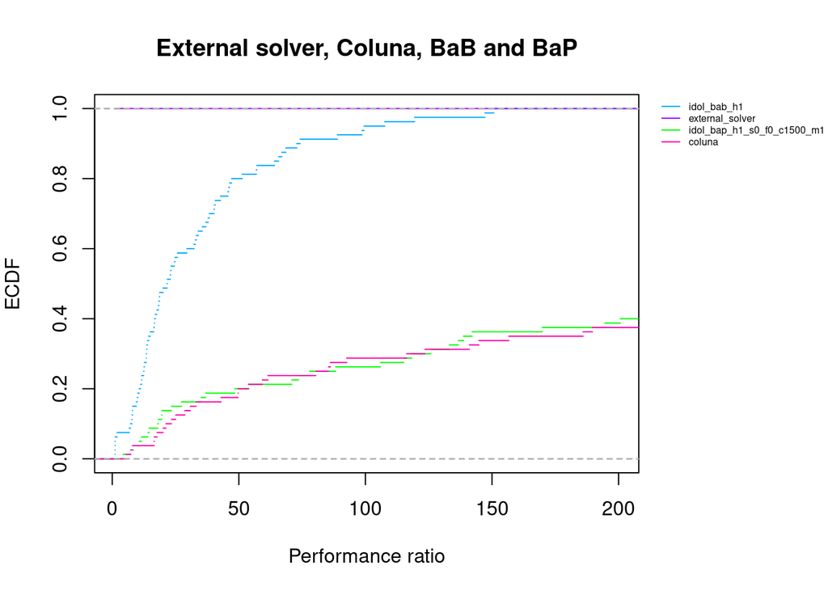

```r
performance_profile(results[results$solver_with_params %in% c("external_solver", "idol_bab_h1", "idol_bap_h1_s0_f0_c1500_m1", "coluna"),], xlim = c(1, 200), main = "External solver, Coluna, BaB and BaP")
```

### Summary tables

We also introduce function `make_table` which builds a summary table from a given dataset where each column is defined as:

- `solver_with_params` the given name of the method ;
- `n_agents` the number of agents of the considered instances ;
- `n_jobs` the number of jobs of the considered instances ;
- `count` the total number of instances which were tried ;
- `unsolved` the number of instances which could not be solved within the given time limit (i.e., within 600 seconds) ;
- `time` the average computation time (over the solved instances only).

```r
make_table = function (dataset) {

  group_by = c("solver_with_params", "n_agents", "n_jobs")

  rownames(dataset) = NULL

  count = aggregate(dataset$time, by = dataset[,group_by], FUN = length)
  colnames(count) = c(group_by, "count")

  unsolved = aggregate(dataset$time >= time_limit, by = dataset[,group_by], FUN = sum)
  colnames(unsolved) = c(group_by, "unsolved")

  errors = aggregate(dataset$status == "ERROR", by = dataset[,group_by], FUN = sum)
  colnames(errors) = c(group_by, "error")

  solved_filter = dataset$time < time_limit
  times = aggregate(dataset[solved_filter,]$time, by = dataset[solved_filter,group_by], FUN = mean)
  colnames(times) = c(group_by, "time")

  Table = merge(count, unsolved, by = group_by)
  Table = merge(Table, errors, by = group_by)
  Table = merge(Table, times, by = group_by)

  return (Table)
}
```

For example, the following table gathers results from the Branch-and-Bound algorithm of idol.

```r
Table = make_table(results[results$solver == "idol_bab",])
```

| solver_with_params | n_agents | n_jobs | count | unsolved | error | time |
| --- | --- | --- | --- | --- | --- | --- |
| idol_bab_h0 | 2 | 30 | 20 | 0 | 0 | 0.0595218 |
| idol_bab_h0 | 2 | 40 | 20 | 0 | 0 | 0.1487588 |
| idol_bab_h0 | 3 | 30 | 20 | 0 | 0 | 0.7318348 |
| idol_bab_h0 | 3 | 40 | 20 | 0 | 0 | 4.8345332 |
| idol_bab_h1 | 2 | 30 | 20 | 0 | 0 | 0.0577298 |
| idol_bab_h1 | 2 | 40 | 20 | 0 | 0 | 0.1448250 |
| idol_bab_h1 | 3 | 30 | 20 | 0 | 0 | 0.6788873 |
| idol_bab_h1 | 3 | 40 | 20 | 0 | 0 | 4.6375644 |

## Computational results

### Branch-and-bound algorithm

In this section, we evaluate the computational benefits obtained by idol’s primal heuristics.

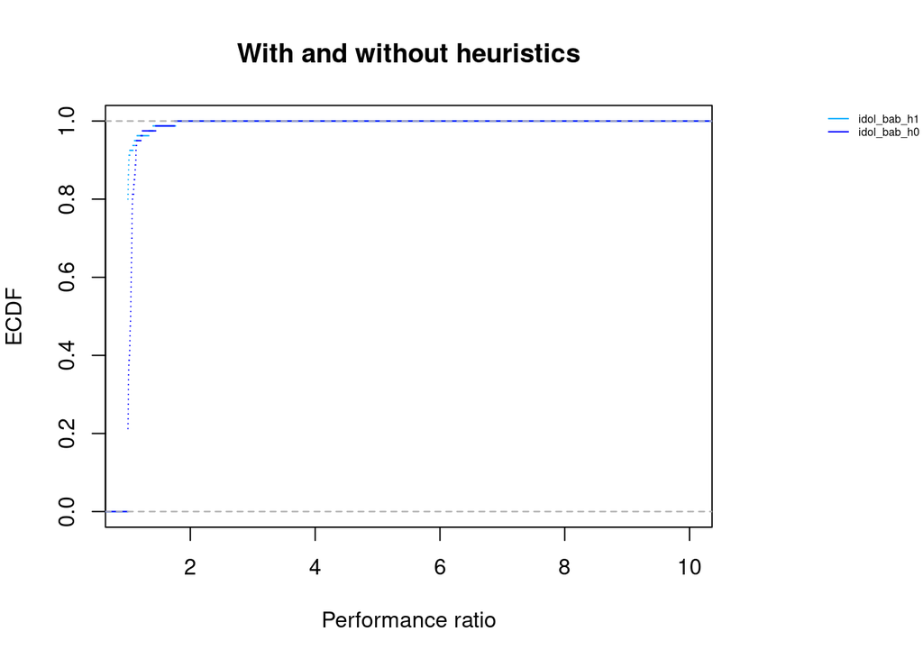

```r
performance_profile(results[results$solver == "idol_bab",], xlim = c(1, 10), main = "With and without heuristics")
```

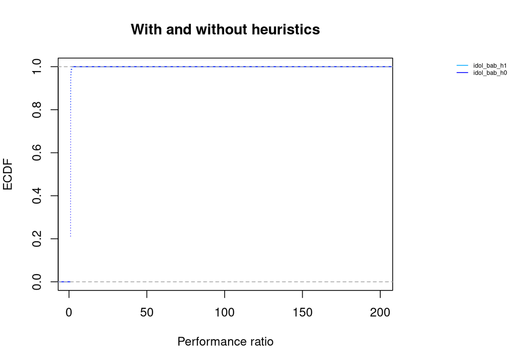

```r
performance_profile(results[results$solver == "idol_bab",], xlim = c(1, 200), main = "With and without heuristics")
```

### Branch and price

#### With coluna

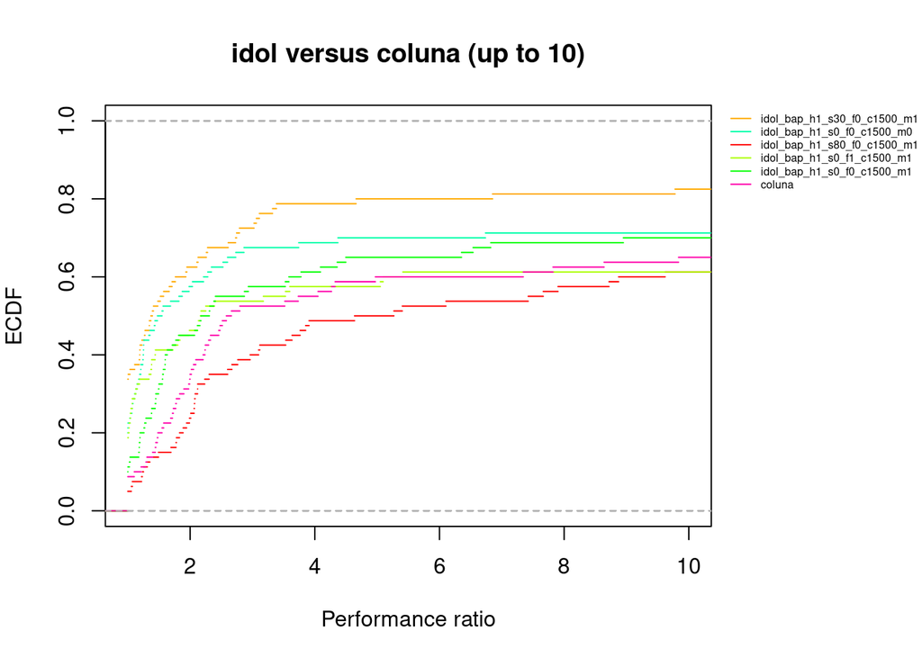

```r
performance_profile(results[results$solver != "external_solver" & results$solver != "idol_bab",], xlim = c(1, 10), main = "idol versus coluna (up to 10)")
```

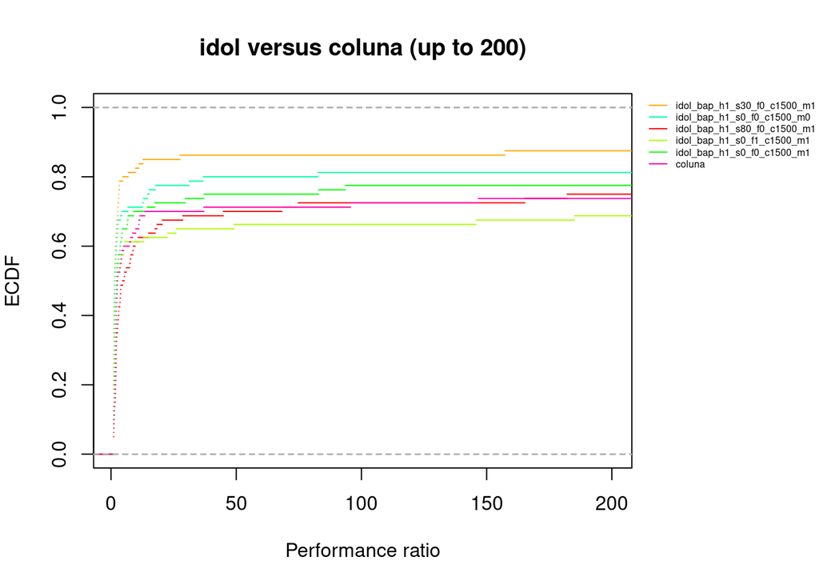

```r
performance_profile(results[results$solver != "external_solver" & results$solver != "idol_bab",], xlim = c(1, 200), main = "idol versus coluna (up to 200)")
```

```r
Table = make_table(results[results$solver_with_params == "idol_bap_h1_s0_f0_c1500_m1" | results$solver_with_params == "coluna",])
```

| solver_with_params | n_agents | n_jobs | count | unsolved | error | time |
| --- | --- | --- | --- | --- | --- | --- |
| coluna | 2 | 30 | 20 | 4 | 4 | 5.044000 |
| coluna | 2 | 40 | 20 | 12 | 12 | 17.801500 |
| coluna | 3 | 30 | 20 | 0 | 0 | 6.392750 |
| coluna | 3 | 40 | 20 | 5 | 5 | 18.907867 |
| idol_bap_h1_s0_f0_c1500_m1 | 2 | 30 | 20 | 5 | 0 | 1.711936 |
| idol_bap_h1_s0_f0_c1500_m1 | 2 | 40 | 20 | 7 | 0 | 17.807279 |
| idol_bap_h1_s0_f0_c1500_m1 | 3 | 30 | 20 | 0 | 0 | 1.174686 |
| idol_bap_h1_s0_f0_c1500_m1 | 3 | 40 | 20 | 6 | 0 | 41.462334 |

We also have a look at pathological instances for idol where the execution time is $20%$ worst than coluna’s time. This is to spot and study why this happens and potentially fix the issue.

```r
find_pathological_instances = function (dataset, solver_a, solver_b) {

  results_a = dataset[dataset$solver_with_params == solver_a,]
  results_b = dataset[dataset$solver_with_params == solver_b,]

  merged = merge(results_a, results_b, by = c("instance"))

  result = merged[ merged$time.y > 1.2 * merged$time.x , c("instance", "time.x", "time.y", "status.x", "status.y")]

  colnames(result) = c("instance", paste0(solver_a, ".time"), paste0(solver_b, ".time"), paste0(solver_a, ".status"), paste0(solver_b, ".status"))

  return ( result )
}

pathological_instances = find_pathological_instances(results, "coluna", "idol_bap_h1_s0_f0_c1500_m1")
```

```r
paged_table(pathological_instances)
```

|  | instance | coluna.time | idol_bap_h1_s0_f0_c1500_m1.time | coluna.status | idol_bap_h1_s0_f0_c1500_m1.status |
| --- | --- | --- | --- | --- | --- |
| 6 | ./GAP/data/n2/instance_n2_30__13.txt | 4.469 | 600.048000 | OPTIMAL | Fail |
| 10 | ./GAP/data/n2/instance_n2_30__17.txt | 0.517 | 0.622488 | OPTIMAL | Optimal |
| 12 | ./GAP/data/n2/instance_n2_30__19.txt | 36.941 | 600.013000 | OPTIMAL | Fail |
| 14 | ./GAP/data/n2/instance_n2_30__3.txt | 6.281 | 600.010000 | OPTIMAL | Fail |
| 15 | ./GAP/data/n2/instance_n2_30__4.txt | 1.201 | 600.006000 | OPTIMAL | Fail |
| 19 | ./GAP/data/n2/instance_n2_30__8.txt | 6.769 | 600.006000 | OPTIMAL | Fail |
| 23 | ./GAP/data/n2/instance_n2_40__10.txt | 1.387 | 41.091400 | OPTIMAL | Optimal |
| 26 | ./GAP/data/n2/instance_n2_40__13.txt | 3.297 | 14.828000 | OPTIMAL | Optimal |
| 33 | ./GAP/data/n2/instance_n2_40__2.txt | 4.005 | 600.002000 | OPTIMAL | Fail |
| 35 | ./GAP/data/n2/instance_n2_40__4.txt | 10.756 | 600.002000 | OPTIMAL | Fail |

[output cut: 13 more lines]

#### Branching on master versus branching on pricing

Comparing branching scheme (on master or on pricing problem) without smoothing, using artificial variables (phase I) and primal heuristics.

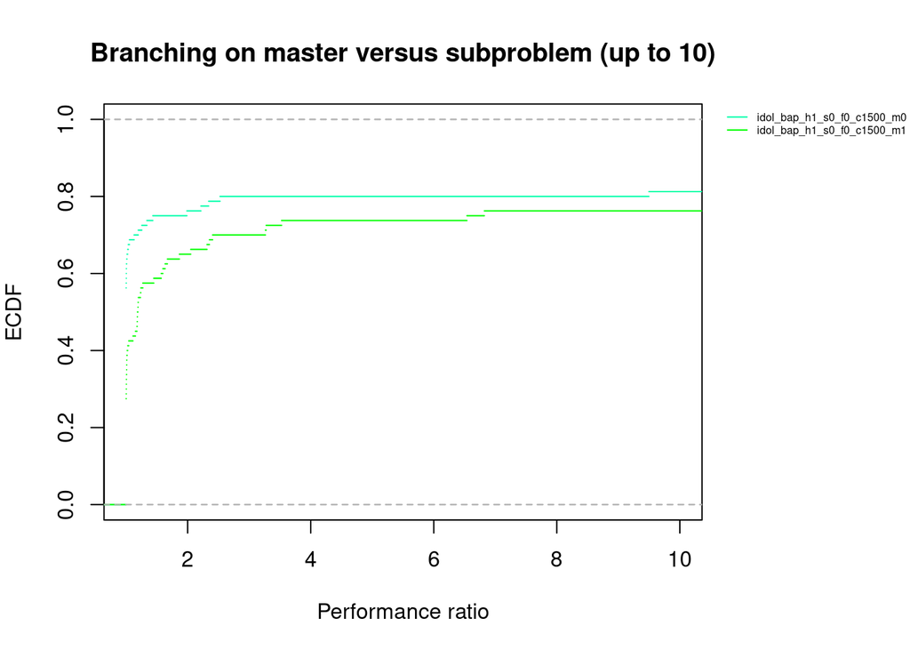

```r
performance_profile(results[results$solver == "idol_bap" & results$with_heuristics == TRUE & results$smoothing_factor == 0 & results$farkas_pricing == 0,], xlim = c(1, 10), main = "Branching on master versus subproblem (up to 10)")
```

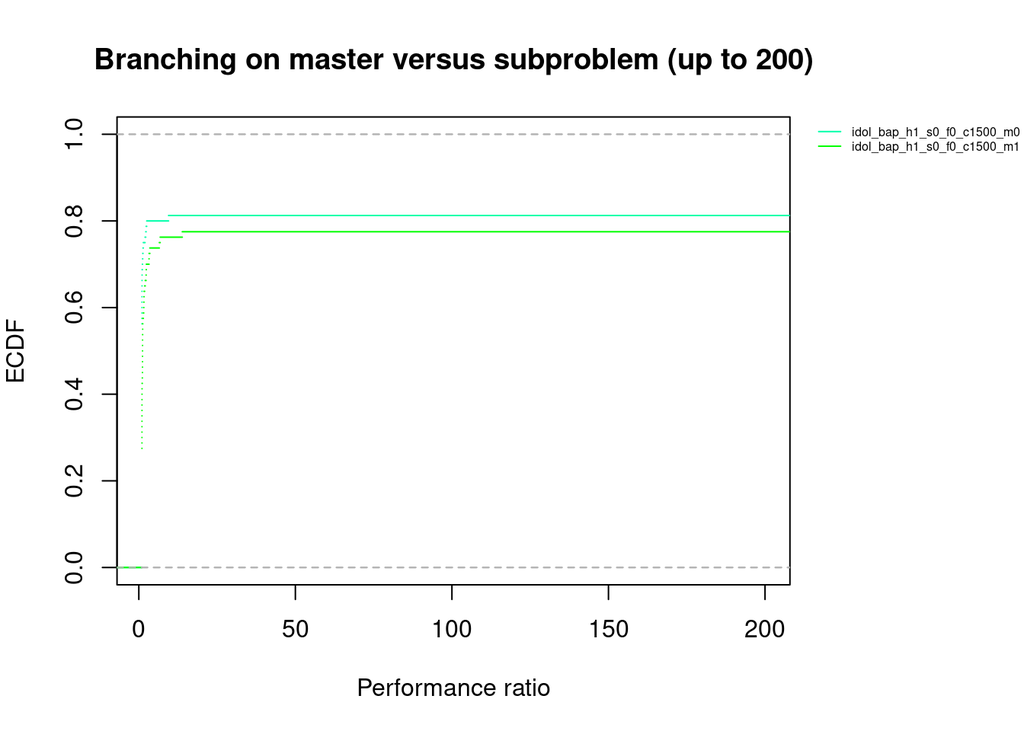

```r
performance_profile(results[results$solver == "idol_bap" & results$with_heuristics == TRUE & results$smoothing_factor == 0 & results$farkas_pricing == 0,], xlim = c(1, 200), main = "Branching on master versus subproblem (up to 200)")
```

#### Using artificial variables versus Farkas pricing

Comparing farkas pricing with artificial variables (phase I) using primal heuristics, master branching and no smoothing.

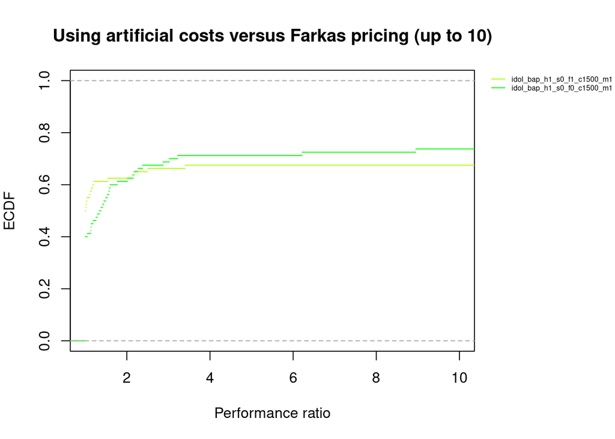

```r
performance_profile(results[results$solver == "idol_bap" & results$with_heuristics == TRUE & results$smoothing_factor == 0 & results$branching_on_master == TRUE,], xlim = c(1, 10), main = "Using artificial costs versus Farkas pricing (up to 10)")
```

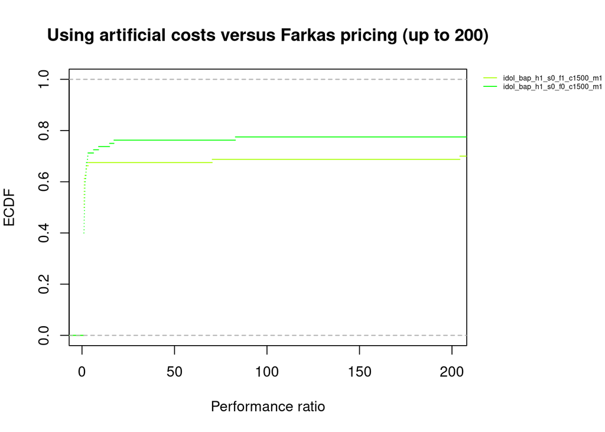

```r
performance_profile(results[results$solver == "idol_bap" & results$with_heuristics == TRUE & results$smoothing_factor == 0 & results$branching_on_master == TRUE,], xlim = c(1, 200), main = "Using artificial costs versus Farkas pricing (up to 200)")
```

#### Smoothing factor

Comparing smoothing factors with artificial variables, master branching and primal heuristics.

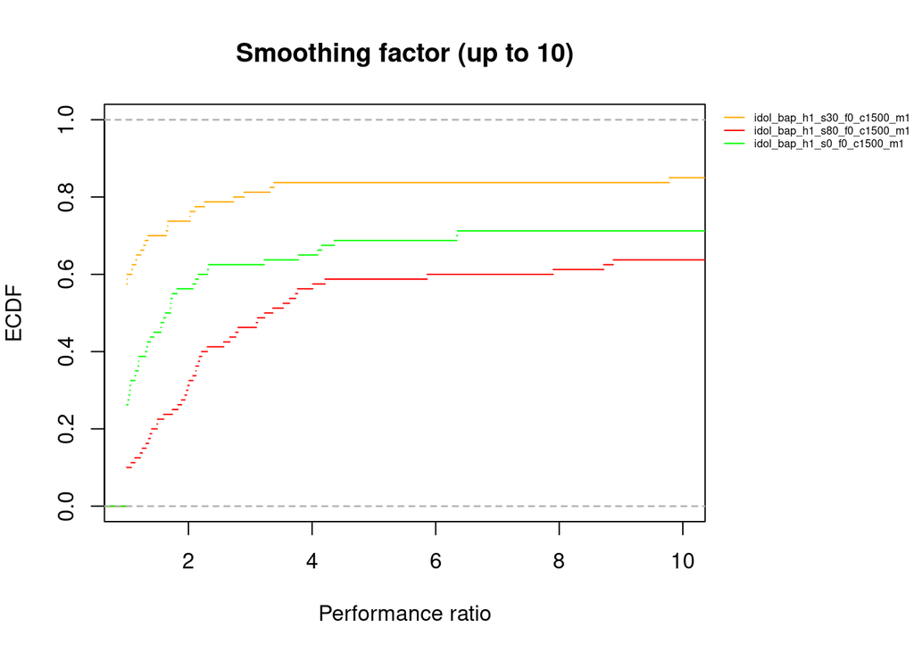

```r
performance_profile(results[results$solver == "idol_bap" & results$with_heuristics == TRUE & results$branching_on_master == TRUE & results$farkas_pricing == 0,], xlim = c(1, 10), main = "Smoothing factor (up to 10)")
```

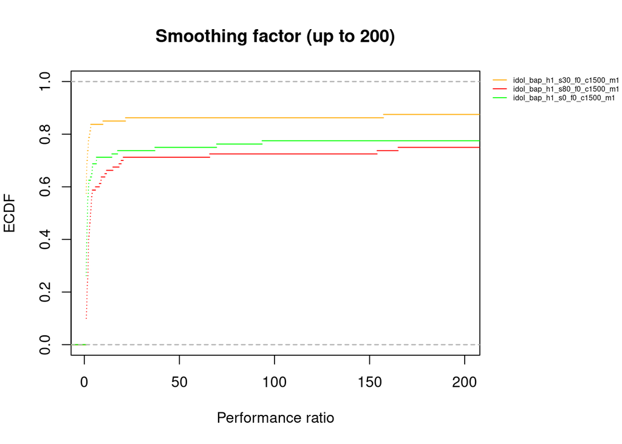

```r
performance_profile(results[results$solver == "idol_bap" & results$with_heuristics == TRUE & results$branching_on_master == TRUE & results$farkas_pricing == 0,], xlim = c(1, 200), main = "Smoothing factor (up to 200)")
```